# Continued Analysis of the Financial Literacy Levels of St. John Fisher University Students

Nate Lewis

Spring 2024

## Background

Financial literacy is often viewed as the ability to understand and effectively use money; this topic incorporates ideas such as personal financial management, budgeting, and investing. Yet, even as financial systems become more prominent due to the increasing access to and influence of the Internet, young people across the globe suffer from low levels of financial literacy (Ramos-Hernández, 2020). Today’s youth, particularly college students, are one of the most vulnerable populations in the financial system and for that reason, it is important to ensure that college students have the tools to become successful “economic citizens” (Amagir, 2017).

The “Financial Knowledge Scale” (FKS) was designed in 2012 by researchers Melissa Knoll and Carrie Houts to accurately measure financial literacy using a 20-item survey (Knoll, 2012) . By utilizing item response theory (IRT), the researchers were able to design an assessment that provides results by analyzing what ability or skill level is needed to secure a certain possibility of answering a question correctly. In 2019, Knoll and Houts revisited their original assessment and improved it using primary data from thousands of households (Knoll, 2019). Using this abundance of new data and a new IRT parameter that analyzes the probability of getting a question correct by chance, the researchers were able to design a more user-friendly 10-item scale without compromising on reliability. The 10-Item Financial Knowledge Scale measures respondents’ financial literacy using a series of multiple-choice and true-false questions. With the researchers’ extensive analysis of previous financial literacy assessments, meticulous focus on evidence-based assessment designing using IRT, and prioritization of user-friendliness, the Financial Knowledge Scale is the best instrument for measuring the financial literacy of college students.

## Data Set

In Fall 2022, I worked with various departments of St. John Fisher University to gather responses to the FKS survey from the Fisher student body, along with demographic data. Although 406 unique responses were recorded, some respondents did not fully complete the survey and a small number of observations could not be used due to “Gender” responses; therefore, the remaining 270 fully complete responses were used for analysis purposes. In Spring 2023, basic regression analysis was done to identify certain trends in the data; however, machine learning and advanced regression methods were not utilized. With this project, I am seeking to address the following research question: *Using machine learning and advanced regression techniques, what is the best model to accurately predict the financial literacy level of Fisher students? How do these techniques help identify which student populations have low financial literacy scores?*

[figure not shown]

## Initial Exploratory Analysis of Data

```r
library(mlbench)
library(caret)
library(partykit)
library(skimr)
library(party)
library(readxl)
```

```r
library(ggcorrplot)
```

Financial literacy scores, along with various demographic characteristics and experience in financial courses, were collected for every survey respondent. The “Score” variable measures how many correct answers a student selected on the 10-question FKS survey. Furthermore, the data set includes dummy variables for age, gender, grade level, academic school at Fisher, and experience with financial courses.

The “read_excel” function is used to import the data set from Excel and the “skim” function verifies that the data set is complete. In addition, the “colnames” function was utilized to rename certain variable and prevent issues with coding and interpretation, as the data set included certain variables with numbers in the title (e.g., the dummy variable for if a student was aged 18 was “18”) and vague names (e.g., the dummy if someone was a male was entitled “Gender”, as opposed to “Male”).

```r
data <- read_excel("C://Users//nml06596//Downloads//Data Set Dummy.xlsx")
skim(data)
```

Data summary

| Name | data |
| --- | --- |
| Number of rows | 270 |
| Number of columns | 19 |
| _______________________ |  |
| Column type frequency: |  |
| numeric | 19 |
| ________________________ |  |
| Group variables | None |

**Variable type: numeric**

| skim_variable | n_missing | complete_rate | mean | sd | p0 | p25 | p50 | p75 | p100 | hist |
| --- | --- | --- | --- | --- | --- | --- | --- | --- | --- | --- |
| Gender | 0 | 1 | 0.37 | 0.48 | 0 | 0 | 0 | 1.00 | 1 | ▇▁▁▁▅ |
| Business | 0 | 1 | 0.31 | 0.47 | 0 | 0 | 0 | 1.00 | 1 | ▇▁▁▁▃ |
| Nursing | 0 | 1 | 0.21 | 0.41 | 0 | 0 | 0 | 0.00 | 1 | ▇▁▁▁▂ |
| Education | 0 | 1 | 0.07 | 0.26 | 0 | 0 | 0 | 0.00 | 1 | ▇▁▁▁▁ |
| Arts & Sciences | 0 | 1 | 0.30 | 0.46 | 0 | 0 | 0 | 1.00 | 1 | ▇▁▁▁▃ |
| Pharmacy | 0 | 1 | 0.10 | 0.30 | 0 | 0 | 0 | 0.00 | 1 | ▇▁▁▁▁ |
| 18 | 0 | 1 | 0.19 | 0.39 | 0 | 0 | 0 | 0.00 | 1 | ▇▁▁▁▂ |
| 19 | 0 | 1 | 0.21 | 0.41 | 0 | 0 | 0 | 0.00 | 1 | ▇▁▁▁▂ |
| 20 | 0 | 1 | 0.17 | 0.38 | 0 | 0 | 0 | 0.00 | 1 | ▇▁▁▁▂ |
| 21 | 0 | 1 | 0.18 | 0.39 | 0 | 0 | 0 | 0.00 | 1 | ▇▁▁▁▂ |
| 22 | 0 | 1 | 0.07 | 0.26 | 0 | 0 | 0 | 0.00 | 1 | ▇▁▁▁▁ |
| 23 or above | 0 | 1 | 0.18 | 0.38 | 0 | 0 | 0 | 0.00 | 1 | ▇▁▁▁▂ |
| First Year | 0 | 1 | 0.20 | 0.40 | 0 | 0 | 0 | 0.00 | 1 | ▇▁▁▁▂ |
| Sophomore | 0 | 1 | 0.21 | 0.41 | 0 | 0 | 0 | 0.00 | 1 | ▇▁▁▁▂ |
| Junior | 0 | 1 | 0.20 | 0.40 | 0 | 0 | 0 | 0.00 | 1 | ▇▁▁▁▂ |
| Senior | 0 | 1 | 0.25 | 0.43 | 0 | 0 | 0 | 0.75 | 1 | ▇▁▁▁▃ |
| Graduate | 0 | 1 | 0.14 | 0.34 | 0 | 0 | 0 | 0.00 | 1 | ▇▁▁▁▁ |
| Course | 0 | 1 | 0.40 | 0.49 | 0 | 0 | 0 | 1.00 | 1 | ▇▁▁▁▅ |
| Score | 0 | 1 | 6.93 | 1.64 | 3 | 6 | 7 | 8.00 | 10 | ▁▃▇▃▃ |

```r
colnames(data) <- c('Male','Business','Nursing','Education','ArtsandSciences','Pharmacy',                  'Age18','Age19','Age20','Age21','Age22',"Age23andup",              'FirstYear','Sophomore','Junior','Senior','Graduate',
'Course','Score')
```

```r
summary(data$Score)
```

```
##    Min. 1st Qu.  Median    Mean 3rd Qu.    Max.
##    3.00    6.00    7.00    6.93    8.00   10.00
```

```r
library(dplyr)
```

However, my previous research identified that this distribution of is not shared equally throughout all populations at Fisher.

The male population at Fisher tends to answer between one to two more questions correctly than their female counterparts.

```r
data %>%
  group_by(Male) %>%
  summarize(median_score = median(Score), mean_score = mean(Score))
```

| Male | median_score | mean_score |
| --- | --- | --- |
| 0 | 6 | 6.458824 |
| 1 | 8 | 7.730000 |

The Business major population at Fisher tends to answer about one to two more questions correctly than their non-Business major counterparts.

```r
data %>%
  group_by(Business, Nursing, Education, ArtsandSciences, Pharmacy) %>%
  summarize(median_score = median(Score), mean_score = mean(Score))
```

```
## 'ArtsandSciences'. You can override using the `.groups` argument.
```

| Business | Nursing | Education | ArtsandSciences | Pharmacy | median_score | mean_score |
| --- | --- | --- | --- | --- | --- | --- |
| 0 | 0 | 0 | 0 | 1 | 7.0 | 6.961538 |
| 0 | 0 | 0 | 1 | 0 | 6.5 | 6.560976 |
| 0 | 0 | 1 | 0 | 0 | 6.0 | 6.315789 |
| 0 | 1 | 0 | 0 | 0 | 6.0 | 6.465517 |
| 1 | 0 | 0 | 0 | 0 | 8.0 | 7.729412 |

Those that have taken a financial course tend to answer about one to two more questions correctly than their counterparts that have never taken a financial course.

```r
data %>%
  group_by(Course) %>%
  summarize(median_score = median(Score), mean_score = mean(Score))
```

| Course | median_score | mean_score |
| --- | --- | --- |
| 0 | 6.0 | 6.549383 |
| 1 | 7.5 | 7.500000 |

Scores tend to increase with age, particularly at age 22 and above.

```r
data %>%
  group_by(Age18, Age19, Age20, Age21, Age22, Age23andup) %>%
  summarize(median_score = median(Score), mean_score = mean(Score))
```

```
## 'Age22'. You can override using the `.groups` argument.
```

| Age18 | Age19 | Age20 | Age21 | Age22 | Age23andup | median_score | mean_score |
| --- | --- | --- | --- | --- | --- | --- | --- |
| 0 | 0 | 0 | 0 | 0 | 1 | 8 | 7.541667 |
| 0 | 0 | 0 | 0 | 1 | 0 | 8 | 7.850000 |
| 0 | 0 | 0 | 1 | 0 | 0 | 7 | 6.897959 |
| 0 | 0 | 1 | 0 | 0 | 0 | 7 | 6.957447 |
| 0 | 1 | 0 | 0 | 0 | 0 | 7 | 6.607143 |
| 1 | 0 | 0 | 0 | 0 | 0 | 6 | 6.340000 |

Scores tend to increase with each subsequent grade level.

```r
data %>%
  group_by(FirstYear, Sophomore, Junior, Senior) %>%
  summarize(median_score = median(Score), mean_score = mean(Score))
```

| FirstYear | Sophomore | Junior | Senior | median_score | mean_score |
| --- | --- | --- | --- | --- | --- |
| 0 | 0 | 0 | 0 | 8 | 7.729730 |
| 0 | 0 | 0 | 1 | 7 | 7.147059 |
| 0 | 0 | 1 | 0 | 7 | 6.909091 |
| 0 | 1 | 0 | 0 | 7 | 6.578947 |
| 1 | 0 | 0 | 0 | 6 | 6.490566 |

Graduate students tend to answer one more questions correctly than their undergraduate counterparts.

```r
data %>%
  group_by(Graduate) %>%
  summarize(median_score = median(Score), mean_score = mean(Score))
```

| Graduate | median_score | mean_score |
| --- | --- | --- |
| 0 | 7 | 6.802575 |
| 1 | 8 | 7.729730 |

There are strong differences across numerous variables, allowing me to use the following model in my previous research to best predict financial literacy scores:

*Score = 7.4 + 0.l5 if Aged 19, 20, or 21 + 1.1 if Aged 22 or above - 0.7 if non-Business - 0.9 if Female*

The model previously identified was able to explain 21.17% of the variance in the sample, with all variable significant at an alpha level of 0.05.

## Principal Component Analysis

```r
data <- read_excel("C://Users//nml06596//Downloads//Data Set Dummy.xlsx")
colnames(data) <- c('Male','Business','Nursing','Education','ArtsandSciences','Pharmacy',                  'Age18','Age19','Age20','Age21','Age22',"Age23andup",              'FirstYear','Sophomore','Junior','Senior','Graduate',
'Course','Score')
```

```r
library(FactoMineR)
library(factoextra)
```

The data set was analyzed for multicollinearity using a correlation matrix and PCA analysis. The only variables that showed excessive correlation were those related to age and grade level. This makes intuitive sense: a majority of Fisher students start college around age 18, right after high school graduation. As a result, being First Year is highly correlated with being aged 18. This trend continues for every subsequent year of age and undergraduate grade level.

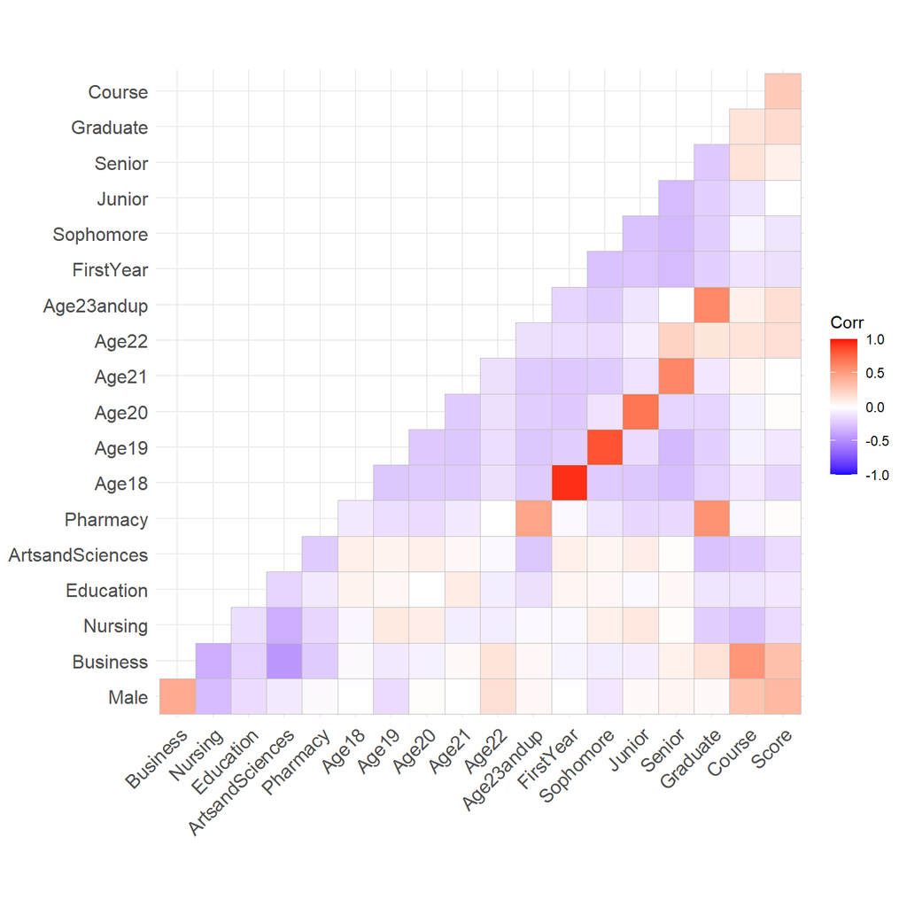

```r
corr_matrix <- cor(data)
ggcorrplot(corr_matrix, type='lower')
```

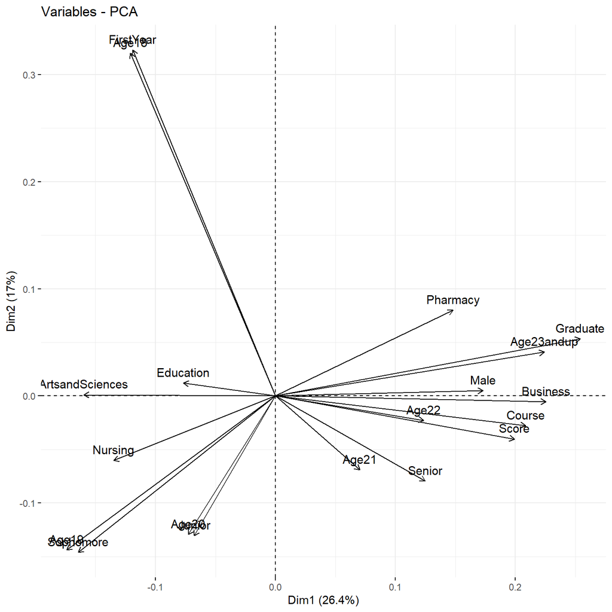

```r
data.pca <- princomp(corr_matrix)
fviz_pca_var(data.pca, col.var = "black")
```

In order to reduce issues associated with multicollinearity, the decision was made to remove either the Age or Grade Level variables. It was decided that it would be better to remove the Grade Level variable as it’s meaning is vaguer in it’s interpretation: when respondents answered the survey, did they consider “First Year” to mean their first year at Fisher or at any higher education institution? Given that it may introducing unreliability into the data set, it was removed. Note that Graduate was kept because it is not necessarily correlated with age; there are many students that start graduate programs directly after undergraduate, but there is also a large population of students who return to school for graduate programs later in life.

```r
data <- subset(data, select = -c(FirstYear, Sophomore, Junior, Senior))
```

After removing the variables related to undergraduate grade levels, the updated correlation matrix reveals that multicollinearity issues have been properly addressed.

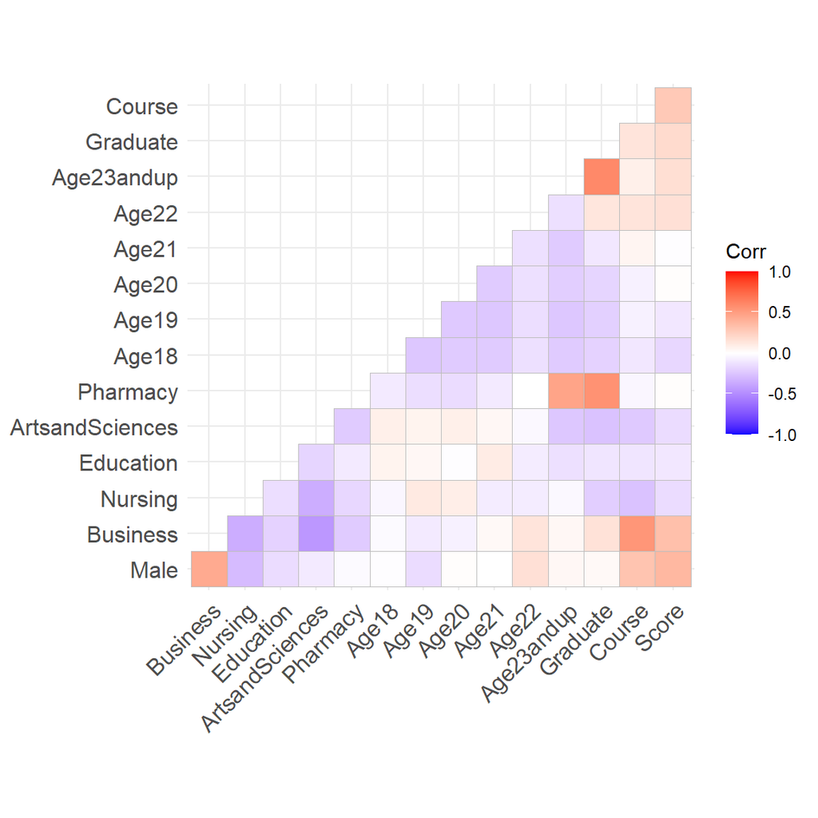

```r
ggcorrplot(cor(data), type='lower')
```

## Data Splitting & Resampling

```r
set.seed(1000)
trainIndex <- createDataPartition(data$Score, p = .9, list = FALSE, times = 1)
train_data <- data[ trainIndex,]
test_data  <- data[-trainIndex,]
ctrl <- trainControl(method="cv", n=4)

mean(train_data$Score)
```

```
## [1] 6.930328
```

```r
mean(test_data$Score)
```

```
## [1] 6.923077
```

## Predicting Scores - Regression Analysis

```r
library(earth) # for MARS
library(glmnet) # for LARS and LASSO
```

```r
library(gridExtra)  # for arranging plot
library(dplyr) # for cleaning the data set
library(ggplot2) # for graph below
```

Various techniques were utilized to develop regression models that help estimate scores. Although interaction effects were briefly considered, they greatly over-complicated models (more than tripling the number of predictors in some models) while also *reducing* the R-squared values of models by around 0.10.

```r
 ctrl <- trainControl(method="cv", number=5)

models <- list(
  m1_lm <- train(Score ~ ., data = train_data, method = "lm", trControl = ctrl),
  m2_ss <- train(Score ~ ., data=train_data, method="glmStepAIC", direction="both",  trControl=ctrl),
  m3_mars <- train(Score ~ . , data=train_data, method="earth", tuneGrid = expand.grid(degree = 1:3, nprune = 1:10), trControl=ctrl),
  m4_elastic <- train(Score ~ . , data=train_data, method="glmnet", tuneLength=10, degree = 2,  trControl=ctrl),
  m5_rf <- train(Score ~ . , data=train_data, method="rf",  trControl=ctrl),
  m6_rpart <- train(Score ~ . , data=train_data, method="rpart",  trControl=ctrl)
)
```

After resampling, all models had R-squared values between 0.10 and 0.20, with one model being able to explain almost 20% of the variation in training data scores (Model 4 = Elastic).

```r
results <-resamples(models)
summary(results)
```

```
##
## Call:
## summary.resamples(object = results)
##
## Models: Model1, Model2, Model3, Model4, Model5, Model6
## Number of resamples: 5
##
## MAE
##             Min.  1st Qu.   Median     Mean  3rd Qu.     Max. NA's
## Model1 1.1243868 1.166264 1.234381 1.221738 1.275655 1.308003    0
## Model2 1.0864893 1.099396 1.236886 1.205460 1.293370 1.311157    0
## Model3 1.0582401 1.064720 1.191740 1.240730 1.397418 1.491530    0
## Model4 0.9715566 1.178455 1.260655 1.194793 1.274889 1.288409    0
## Model5 1.0274552 1.147590 1.174847 1.207635 1.336139 1.352146    0
## Model6 1.1736035 1.174232 1.198890 1.216147 1.220527 1.313481    0
##
## RMSE
##            Min.  1st Qu.   Median     Mean  3rd Qu.     Max. NA's
## Model1 1.418460 1.433521 1.527708 1.534353 1.573419 1.718655    0
## Model2 1.376603 1.461174 1.475597 1.529444 1.565572 1.768274    0
## Model3 1.253501 1.307670 1.443299 1.506142 1.642143 1.884094    0
## Model4 1.249380 1.463646 1.504467 1.484348 1.535115 1.669132    0
## Model5 1.254873 1.474622 1.525488 1.501129 1.614164 1.636500    0
## Model6 1.461318 1.474471 1.500146 1.534347 1.611691 1.624108    0
##
## Rsquared
##               Min.    1st Qu.    Median      Mean   3rd Qu.      Max. NA's
## Model1 0.022574539 0.08814079 0.1130907 0.1552064 0.1687579 0.3834679    0
## Model2 0.077060441 0.07842037 0.1818473 0.1522965 0.1826711 0.2414834    0
## Model3 0.009487396 0.17452659 0.1904795 0.1728252 0.2003145 0.2893180    0
## Model4 0.127760270 0.16230043 0.1803789 0.1879405 0.1984925 0.2707704    0
## Model5 0.035771999 0.10112239 0.1017128 0.1720552 0.2659325 0.3557363    0
## Model6 0.056995437 0.10602818 0.1274770 0.1367531 0.1886894 0.2045755    0
```

[figure not shown]

```r
# Predictions based on the test_data

preds_lm <- predict(m1_lm, test_data)
preds_ss <- predict(m2_ss, test_data)
preds_mars <- predict(m3_mars, test_data)
preds_lasso <- predict(m4_elastic, test_data)
preds_rf <- predict(m5_rf, test_data)
preds_rpart <- predict(m6_rpart, test_data)

plot1 <- ggplot(test_data, aes(x = Score, y = preds_lm)) +
  geom_point(color = "yellow") +
  geom_abline(intercept = 0, slope = 1, linetype = "dashed", color = "black") +
  labs(title = "LM Predictions", x = "Actual Score", y = "Predicted Score") +
  theme_bw()

plot2 <- ggplot(test_data, aes(x = Score, y = preds_ss)) +
  geom_point(color = "blue") +
  geom_abline(intercept = 0, slope = 1, linetype = "dashed", color = "black") +
  labs(title = "Stepwise Predictions", x = "Actual Score", y = "Predicted Score") +
  theme_bw()

plot3 <- ggplot(test_data, aes(x = Score, y = preds_mars)) +
  geom_point(color = "green") +
  geom_abline(intercept = 0, slope = 1, linetype = "dashed", color = "black") +
  labs(title = "MARS Predictions", x = "Actual Score", y = "Predicted Score") +
  theme_bw()

plot4 <- ggplot(test_data, aes(x = Score, y = preds_lasso)) +
  geom_point(color = "red") +
  geom_abline(intercept = 0, slope = 1, linetype = "dashed", color = "black") +
  labs(title = "Elastic Predictions", x = "Actual score", y = "Predicted Score") +
  theme_bw()

plot5 <- ggplot(test_data, aes(x = Score, y = preds_lm)) +
  geom_point(color = "red") +
  geom_abline(intercept = 0, slope = 1, linetype = "dashed", color = "black") +
  labs(title = "Random Forest Predictions", x = "Actual score", y = "Predicted Score") +
  theme_bw()

plot6 <- ggplot(test_data, aes(x = Score, y = preds_rpart)) +
  geom_point(color = "red") +
  geom_abline(intercept = 0, slope = 1, linetype = "dashed", color = "black") +
  labs(title = "Rpart Predictions", x = "Actual score", y = "Predicted Score") +
  theme_bw()

# Arrange the plots in a 3-column grid
grid.arrange(plot1, plot2, plot3, plot4, plot5, plot6, ncol = 3)
```

```r
# How well did we predict in the testing data?

r2_lm <- round(summary(lm(test_data$Score ~ preds_lm))$r.squared,2)
r2_ss <- round(summary(lm(test_data$Score ~ preds_ss))$r.squared,2)
r2_mars <- round(summary(lm(test_data$Score ~ preds_mars))$r.squared,2)
r2_elastic <- round(summary(lm(test_data$Score ~ preds_lasso))$r.squared,2)
r2_rf <- round(summary(lm(test_data$Score ~ preds_rf))$r.squared,2)
r2_rpart <- round(summary(lm(test_data$Score ~ preds_rpart))$r.squared,2)

print(paste0("R-squared LM:", r2_lm))
```

```
## [1] "R-squared LM:0.28"
```

```r
print(paste0("R-squared STEPWISE:", r2_ss))
```

```
## [1] "R-squared STEPWISE:0.31"
```

```r
print(paste0("R-squared MARS:", r2_mars))
```

```
## [1] "R-squared MARS:0.14"
```

```r
print(paste0("R-squared ELASTIC:", r2_elastic))
```

```
## [1] "R-squared ELASTIC:0.3"
```

```r
print(paste0("R-squared RF:", r2_rf))
```

```
## [1] "R-squared RF:0.21"
```

```r
print(paste0("R-squared rpart:", r2_rpart))
```

```
## [1] "R-squared rpart:0.14"
```

I selected the stepwise regression as the best model to estimate specific financial literacy scores as it had the highest prediction power (R-squared value = 0.31) and easy interpretability.

The model was estimated as:

```r
m2_ss
```

```
## Generalized Linear Model with Stepwise Feature Selection
##
## 244 samples
##  14 predictor
##
## No pre-processing
## Resampling: Cross-Validated (5 fold)
## Summary of sample sizes: 196, 196, 195, 194, 195
## Resampling results:
##
##   RMSE      Rsquared   MAE
##   1.529444  0.1522965  1.20546
```

```r
summary(m2_ss$finalModel)
```

```
##
## Call:
## NULL
##
## Coefficients:
##             Estimate Std. Error t value Pr(>|t|)
## (Intercept)   6.8071     0.2203  30.904  < 2e-16 ***
## Male          0.8691     0.2201   3.949 0.000104 ***
## Business      0.4412     0.2547   1.732 0.084515 .
## Age18        -1.0113     0.2894  -3.495 0.000567 ***
## Age19        -0.6892     0.2858  -2.412 0.016647 *
## Age20        -0.4267     0.2869  -1.487 0.138259
## Age21        -0.5303     0.2893  -1.833 0.068040 .
## Course        0.3502     0.2309   1.516 0.130795
## ---
## Signif. codes:  0 '***' 0.001 '**' 0.01 '*' 0.05 '.' 0.1 ' ' 1
##
## (Dispersion parameter for gaussian family taken to be 2.141005)
##
##     Null deviance: 651.82  on 243  degrees of freedom
## Residual deviance: 505.28  on 236  degrees of freedom
## AIC: 888.06
##
## Number of Fisher Scoring iterations: 2
```

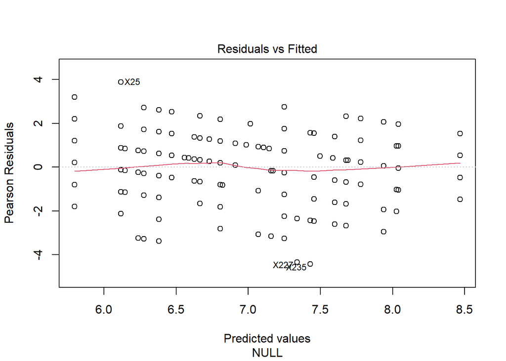

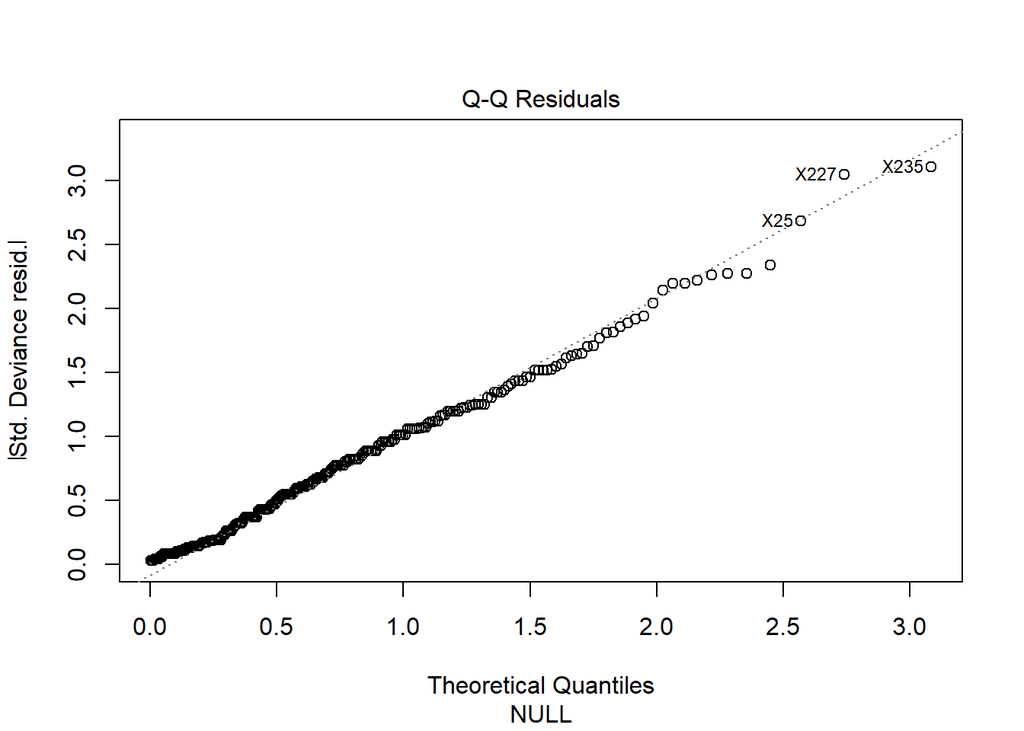

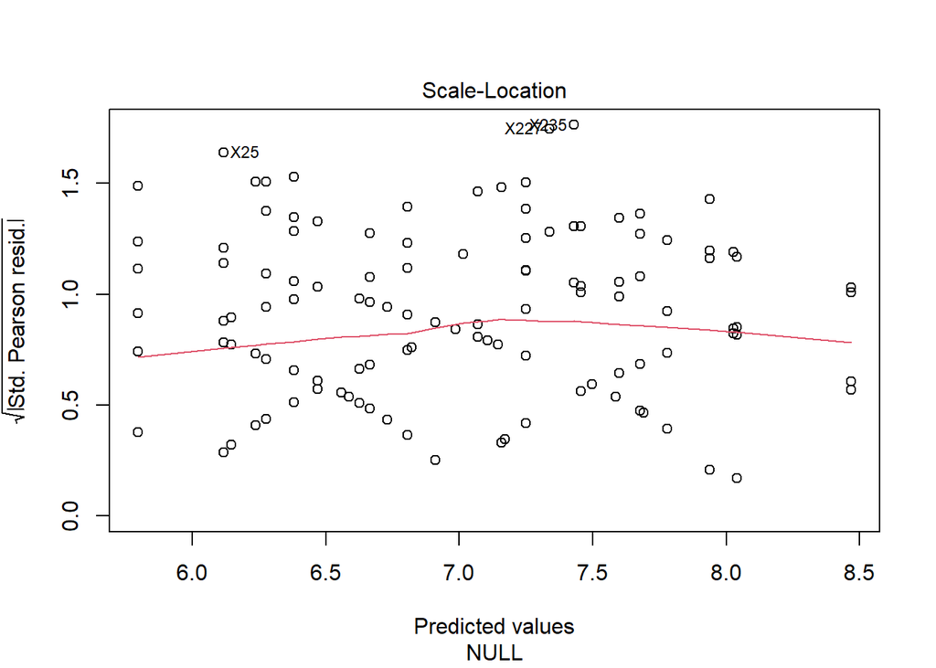

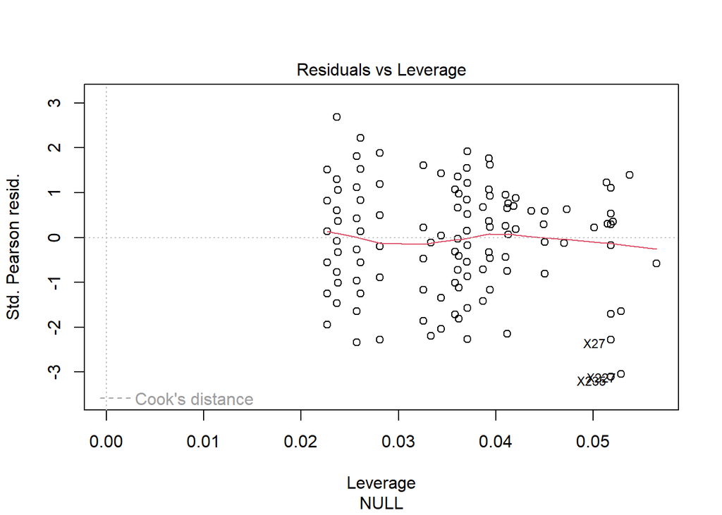

```r
plot(m2_ss$finalModel)
```

Futhermore, this model suffers from minimal heteroskedasticity concerns.

## Predicting Scores - Neural Net Analysis

When I began my project of utilizing machine learning to improve my findings related to the financial literacy of Fisher students, I found the use of neural nets to be a promising idea to help uncover patterns hidden in my data. In specific, I attempted some analysis using the “neuralnet” package, which can be tuned to include specific amounts of nodes in each subsequent layer of analysis. Despite the allure of this package, it was not able to yield any substantial insights for my data set for a few reasons:

1. Running neural nets requires a high amount of computational power and time that was frankly not necessary given the small size of my data set (n < 300)
2. The accuracy of neural nets paled in comparison to those of much simpler models

## Predicting Scores - Decision Tree Analysis

Using decision tree analysis from both the “ctree” and “ctree2” methods indicates that the best predictor of financial literacy scores is gender. Although the decision trees are easy to interpret and emphasize the importance of gender, the fact that the r-squared values hover around 0.15 means that the ctree method explains almost half as much data as the regression models above. As a result, it appears the decision trees are sacrificing some complexity that may in fact be relevant.

```r
models <- list(
  m1_ctree <- train(Score ~ . , data=train_data, method="ctree", trControl = ctrl),
  m2_ctree2 <- train(Score ~ . , data=train_data, method="ctree2", trControl = ctrl)
  )

#comparing the models
results <- resamples(models)
summary(results)
```

```
##
## Call:
## summary.resamples(object = results)
##
## Models: Model1, Model2
## Number of resamples: 5
##
## MAE
##            Min.  1st Qu.  Median     Mean  3rd Qu.    Max. NA's
## Model1 1.228505 1.232000 1.25979 1.255002 1.271894 1.28282    0
## Model2 1.189736 1.207673 1.21658 1.240743 1.271525 1.31820    0
##
## RMSE
##            Min.  1st Qu.   Median     Mean  3rd Qu.     Max. NA's
## Model1 1.500753 1.516527 1.528005 1.553005 1.604875 1.614865    0
## Model2 1.384765 1.471308 1.481810 1.520844 1.626086 1.640250    0
##
## Rsquared
##              Min.    1st Qu.    Median      Mean   3rd Qu.      Max. NA's
## Model1 0.01893222 0.09191583 0.1049585 0.1184998 0.1772996 0.1993931    0
## Model2 0.02658807 0.11477378 0.2051773 0.1584910 0.2128223 0.2330935    0
```

```r
difs <- diff(results)
summary(difs)
```

```
##
## Call:
## summary.diff.resamples(object = difs)
##
## p-value adjustment: bonferroni
## Upper diagonal: estimates of the difference
## Lower diagonal: p-value for H0: difference = 0
##
## MAE
##        Model1 Model2
## Model1        0.01426
## Model2 0.6886
##
## RMSE
##        Model1 Model2
## Model1        0.03216
## Model2 0.6312
##
## Rsquared
##        Model1 Model2
## Model1        -0.03999
## Model2 0.5953
```

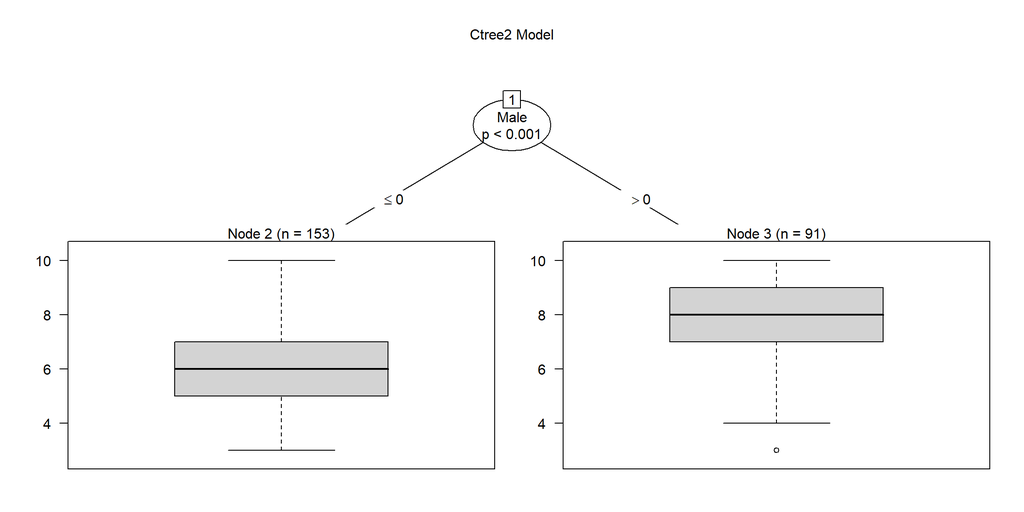

```r
plot((m2_ctree2$finalModel), main = "Ctree2 Model")
```

## Limitations of Predicting Scores

Despite the promising allure of being able to accurately predict students’ exact financial literacy levels, the current data on hand is limited by the fact that there is not enough information on the students surveyed. Although some models were able to predict nearly 30% of differences between scores, 70% of the data is still unexplained. Some of my other research done at Fisher indicates that habits and attitudes developed during childhood play an important role in financial literacy, but without this data collected for participants (as well as factoring in the effect of students merely guessing on questions), the ability of my models to precisely estimate exact scores may be limited.

## Predicting Groups - Cluster Analysis

Even if exact scores cannot be predicted, it is useful to understand which student populations at Fisher can be considered “at-risk” of not having adequate financial literacy levels. The second half of my analysis aims to understand which groups of students typically “fail” the financial literacy assessment.

Note: the idea of a specific number of questions that must be answered correctly to be considered as “passing scores” is entirely subjective. For purposes of this research, I consider a score below 7 as “failing”, with grades of 65% or below typically being considered a failing grade in higher education.

I first looked to group students based on similar characteristics utilizing the clustering tools from the “factoextra” package.

```r
library(factoextra)
library(caret)
library(dplyr)
library(skimr)
```

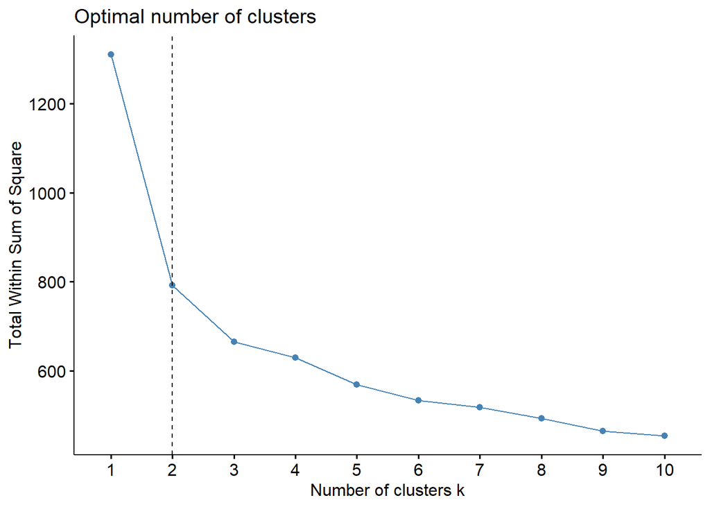

```r
fviz_nbclust(data[,1:15], kmeans, method = "wss") +
  geom_vline(xintercept = 2, linetype = 2)
```

After generating 2 clusters, the following subpopulation of Fisher students were identified:

- “At-Risk Population” with a Score of 5.3: Younger females that have not taken financial courses
- “Average Students” with a Score of 8.1: Typical students at Fisher, weighted towards older Business students that have taken a financial course.

```r
score_clusters <- kmeans(data[,1:15], centers=2)
data$cluster <- score_clusters$cluster
score_clusters$size
```

```
## [1] 160 110
```

```r
score_clusters$centers
```

```
##     Male  Business   Nursing  Education ArtsandSciences   Pharmacy     Age18
## 1 0.4875 0.4125000 0.1750000 0.05625000       0.2562500 0.10000000 0.1187500
## 2 0.2000 0.1727273 0.2727273 0.09090909       0.3727273 0.09090909 0.2818182
##       Age19     Age20   Age21      Age22 Age23andup   Graduate    Course
## 1 0.1875000 0.2000000 0.16875 0.10625000  0.2187500 0.16875000 0.5062500
## 2 0.2363636 0.1363636 0.20000 0.02727273  0.1181818 0.09090909 0.2454545
##      Score
## 1 8.056250
## 2 5.290909
```

It is important to note that the clusters are not entirely accurate, as some students may fit into both clusters.

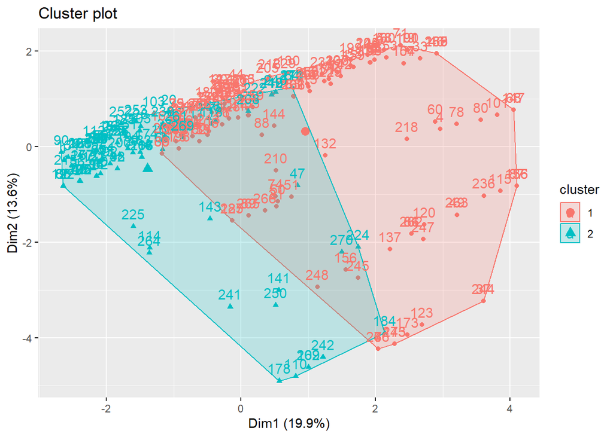

```r
fviz_cluster(score_clusters, data=data)
```

For example, although young females that have not taken a course are considered “At-Risk”, not all in the cluster failed the assessment.

```r
data %>%
  group_by(Male, Age18, Course) %>%
  summarise(max(Score))
```

| Male | Age18 | Course | max(Score) |
| --- | --- | --- | --- |
| 0 | 0 | 0 | 10 |
| 0 | 0 | 1 | 9 |
| 0 | 1 | 0 | 9 |
| 0 | 1 | 1 | 7 |
| 1 | 0 | 0 | 10 |
| 1 | 0 | 1 | 10 |
| 1 | 1 | 0 | 9 |
| 1 | 1 | 1 | 9 |

## Predicting Groups - Decision Tree Analysis

The decision tree analysis was also brought back to identify “at-risk” groups of students, as opposed to predicting specific scores.

```r
data <- read_excel("C://Users//nml06596//Downloads//Data Set Dummy.xlsx")
colnames(data) <- c('Male','Business','Nursing','Education','ArtsandSciences','Pharmacy',                  'Age18','Age19','Age20','Age21','Age22',"Age23andup",              'FirstYear','Sophomore','Junior','Senior','Graduate',
'Course','Score')
data <- subset(data, select = -c(FirstYear, Sophomore, Junior, Senior))
data$Score <- cut(data$Score, breaks = c(0, 6, 10), labels = c('Fail', 'Pass'))
```

```r
set.seed(270)
trainIndex <- createDataPartition(data$Score, p = .9, list = FALSE, times = 1)
train_data <- data[ trainIndex,]
test_data  <- data[-trainIndex,]
ctrl <- trainControl(method="cv", n=5)
```

```r
models <- list(
  m1_ctree <- train(Score ~ ., data=train_data, method="ctree", trControl = ctrl),
  m2_ctree2 <- train(Score ~ ., data=train_data, method="ctree2", trControl = ctrl)
  )

results <- resamples(models)
summary(results)
```

```
##
## Call:
## summary.resamples(object = results)
##
## Models: Model1, Model2
## Number of resamples: 5
##
## Accuracy
##             Min.   1st Qu.    Median      Mean   3rd Qu.      Max. NA's
## Model1 0.6326531 0.6326531 0.6875000 0.6751701 0.6938776 0.7291667    0
## Model2 0.5416667 0.5918367 0.6666667 0.6375850 0.6734694 0.7142857    0
##
## Kappa
##              Min.   1st Qu.    Median     Mean   3rd Qu.      Max. NA's
## Model1  0.2025316 0.2840909 0.3188137 0.317668 0.3283582 0.4545455    0
## Model2 -0.0134357 0.1680815 0.3134851 0.242017 0.3333333 0.4086207    0
```

```r
difs <- diff(results)
summary(difs)
```

```
##
## Call:
## summary.diff.resamples(object = difs)
##
## p-value adjustment: bonferroni
## Upper diagonal: estimates of the difference
## Lower diagonal: p-value for H0: difference = 0
##
## Accuracy
##        Model1 Model2
## Model1        0.03759
## Model2 0.1118
##
## Kappa
##        Model1 Model2
## Model1        0.07565
## Model2 0.3203
```

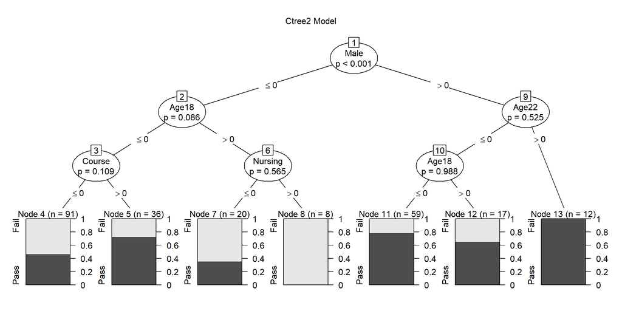

```r
plot((m2_ctree2$finalModel), main = "Ctree2 Model")
```

## Conclusion and Next Steps

In many ways, this extension of my original research was promising in some ways, but unfruitful in others. In terms of findings, it confirms that the included explanatory variables are relevant for understanding the financial literacy of students at St. John Fisher University. This is particularly true when looking at the gender and age variables, with machine learning confirming that findings of female students and younger students having lower financial literacy are accurate and not a result of researcher bias. In addition, tools such as decision trees are incredibly powerful tools for illustrating effects of various variables on financial literacy levels.

From a policy perspective at Fisher, this research lends support for establishing initiatives for improving financial literacy levels of certain student populations, specifically young female students typically in the School of Nursing. Potential programs could include embedding a financial literacy “crash course” into the SJF Nursing program. Although some will look at my analysis to claim that financial courses had a negligible effect on financial literacy courses, this may be attributed to the fact that these effective courses are seldom offered to and participated in by those in “at-risk” populations.

However, my research makes it clear that machine learning and advanced regression techniques cannot solve a basic issue with the data set: not enough variables. The fact that even the best models can only explain 30% of the differences in financial literacy scores implies that better models can only be developed with the inclusion of more information about participants. I suspect that further research that incorporates variables about participants’ socioeconomic status and habits reinforced during their upbringing may be far more accurate at predicting financial literacy levels and detecting “at-risk” populations within the Fisher community.

## Works Cited

Ramos-Hernández, Jésica Josefina, et al. (2020, March 5). Financial Literacy Level on College Students: A Comparative Descriptive Analysis between Mexico and Colombia. *European Journal of Contemporary Education*, vol. 9, no. 1. 10.13187/ejced.2020.1.126.

Amagir, Aisa, et al. (2017, July 13). A Review of Financial-Literacy Education Programs for Children and Adolescents. *Citizenship, Social, and Economics Education*, vol. 17, no. 1, Pages 56–80. 10.1177/2047173417719555.

Knoll, Melissa A. Z., and Carrie R. Houts. (2012, August 30). The Financial Knowledge Scale: An Application of Item Response Theory to the Assessment of Financial Literacy. *Journal of Consumer Affairs*, vol. 46, no. 3, Pages 381-410. 10.1111/j.1745-6606.2012.01241.x.

Knoll, Melissa A. Z., and Carrie R. Houts. (2019, December 3). The Financial Knowledge Scale: New Analyses, Finding, and Development of a Short Form. *Journal of Consumer Affairs*, vol. 54, no. 2. 10.1111/joca.12288.